# An Example of Simulating a Trial with Adaptive Design

In this vignette, we illustrate how to use `TrialSimulator` to simulate a trial with seamless adaptive design of multiple endpoints, where dose selection, futility analysis, interim analysis are triggered by user-defined milestones. Family-wise error rate are controlled by closed test with Dunnett’s test, with $\alpha$ split for the endpoints. Please refer to another vignette where graphical testing procedure is adopted instead.

## Simulation Settings

- Trial consists of two active arms of high or low dose, and a placebo arm.
- Patients are randomized into the trial with ratio `1:1:1`.
- 30 patients are randomized per month for the first 10 months, and 50 patients per month after then until 1000 patients.
- Dropout rate is 8% at month 12, and 18% at month 18, which is modeled by a Weibull distribution. The scale and shape parameters of the Weibull distribution can be computed using helper function

```r
weibullDropout(time = c(12, 18), dropout_rate = c(.08, .18))
```

```
#>     shape     scale
#>  2.138567 38.343517
```

- Two time-to-event endpoints (`PFS` and `OS`) and a binary `surrogate` are under consideration, where a higher rate of `surrogate` is better.
- `surrogate` has a readout time of 5 weeks.
- `surrogate` is used for dose selection using a hypothetical rule. Let $z_h$ (or $z_l$) be the z statistics of `surrogate` between high (or low) dose and placebo.
  - low dose arm is selected if $z_l > 1.28$;
  - high dose arm is selected if $z_h > 1.28 > z_l$;
  - keep both arms otherwise.
- Rates of `surrogate` are
  - 0.05 in placebo
  - 0.12 in low dose arm
  - 0.13 in high dose arm
- Medians of PFS are
  - 5 months in placebo
  - 6.7 months in low dose arm (hazard ratio 0.75)
  - 7.1 months in high dose arm (hazard ratio 0.70) Exponential distribution is assumed.
- Medians of OS are
  - 14 months in placebo
  - 17.5 months in low dose arm (hazard ratio 0.80)
  - 18.2 months high dose arms (hazard ratio 0.77)
- Dose selection is done when 300 patients are randomized with readout of `surrogate` are ready for analysis.
- An interim is set to test `PFS` when 300 `PFS` events are observed. A non-binding futility analysis is also done with a boundary 0.5.
- Final analysis is set for `PFS` and `OS` when all planned 1000 patients are randomized and at least 300 `OS` events are observed. Meanwhile, the trial has reached at least 28 months or at least 520 events are observed for `PFS`.
- To control the family-wise error rate accounting for `PFS` and `OS`, as well as adaptation of dose-selection, we split $\alpha$ between `PFS` (0.5%) and `OS` (2%), and adopt closed test with Dunnett’s test for intersection hypotheses.

## Define Three Arms

In this example, we call `endpoint()` twice for each arm to define `PFS` and `OS`. This implicitly assumes independence between the two time-to-event endpoints. `TrialSimulator` offers a built-in generator `CorrelatedPfsAndOs3()` to generate `PFS` and `OS` with correlation based on the ill-death model, which enjoys several nice properties. For selection of its arguments (i.e. transition hazards), refer to vignette Simulate Correlated Progression-Free Survival and Overall Survival as Endpoints in Clinical Trials.

```r
#' define three arms
pbo <- arm(name = 'placebo')
low <- arm(name = 'low dose')
high <- arm(name = 'high dose')

#' define endpoints in placebo
pfs <- endpoint(name = 'pfs', type = 'tte',
                generator = rexp, rate = log(2) / 5)

os <- endpoint(name = 'os', type = 'tte',
               generator = rexp, rate = log(2) / 14)

five_weeks <- 5 / 52 * 12 ## convert it in months
surrogate <- endpoint(name = 'surrogate', type = 'non-tte',
                      readout = c(surrogate = five_weeks),
                      generator = rbinom, size = 1, prob = .05)
pbo$add_endpoints(pfs, os, surrogate)

#' define endpoints in low dose arm
pfs <- endpoint(name = 'pfs', type = 'tte',
                generator = rexp, rate = log(2) / 6.7)

os <- endpoint(name = 'os', type = 'tte',
               generator = rexp, rate = log(2) / 17.5)

surrogate <- endpoint(name = 'surrogate', type = 'non-tte',
                      readout = c(surrogate = five_weeks),
                      generator = rbinom, size = 1, prob = .12)
low$add_endpoints(pfs, os, surrogate)

#' define endpoints in high dose arm
pfs <- endpoint(name = 'pfs', type = 'tte',
                generator = rexp, rate = log(2) / 7.1)

os <- endpoint(name = 'os', type = 'tte',
               generator = rexp, rate = log(2) / 18.2)

surrogate <- endpoint(name = 'surrogate', type = 'non-tte',
                      readout = c(surrogate = five_weeks),
                      generator = rbinom, size = 1, prob = .13)
high$add_endpoints(pfs, os, surrogate)
```

## Define a Trial

```r
accrual_rate <- data.frame(end_time = c(10, Inf),
                           piecewise_rate = c(30, 50))
trial <- trial(
  name = 'Trial-3415', n_patients = 1000,
  seed = 1727811904, duration = 40,
  enroller = StaggeredRecruiter, accrual_rate = accrual_rate,
  dropout = rweibull, shape = 2.139, scale = 38.343
)

trial$add_arms(sample_ratio = c(1, 1, 1), low, high, pbo)
```

```
#> Arm(s) <low dose, high dose, placebo> are added to the trial.
#> Randomization is done for 1000 potential patients.
#> Data of 1000 potential patients are generated for the trial with 3 arm(s) <low dose, high dose, placebo>.
```

## Define Trial Milestones and Action Functions

Next, we define action functions for trial milestones, i.e., dose selection, interim and final analysis. Note that an action function should always has argument `trial` returned from `trial()`. We calculate z statistics of the Farrington-Manning test for binary endpoint `surrogate` using helper function `fitFarringtonManning`, which returns a data frame (see `?fitFarringtonManning`).

```r
action1 <- function(trial){

  locked_data <- trial$get_locked_data('dose selection')

  fit <- fitFarringtonManning(endpoint = 'surrogate', placebo = 'placebo',
                              data = locked_data, alternative = 'greater')

  # browser() ## if you want to see what does fit look like
  z_l <- fit$z[fit$arm == 'low dose']
  z_h <- fit$z[fit$arm == 'high dose']
  if(z_l > 1.28){
    trial$remove_arms('high dose')
    trial$save(value = 'low', name = 'kept_arm')
  }else if(z_h > 1.28){
    trial$remove_arms('low dose')
    trial$save(value = 'high', name = 'kept_arm')
  }else{
    trial$save(value = 'both', name = 'kept_arm')
  }

}
```

At the interim, we test `PFS` using the logrank test to carry out a non-binding futility analysis in the following action function. Depending on how many arms are carried forward in dose selection, `fit` may consists of testing results of one or two dose arms. Note that a formal test for `PFS` will be done at the end of the trial when we have all p-values. If no futility analysis is planned, we can simply set `action = doNothing` in `milestone`.

```r
action2 <- function(trial){

  locked_data <- trial$get_locked_data('interim')

  fit <- fitLogrank(Surv(pfs, pfs_event) ~ arm, placebo = 'placebo',
                    data = locked_data, alternative = 'less')

  ## futility analysis
  if(max(fit$z) < .5){
    trial$save(value = 'negative', name = 'futility')

    ## extend duration
    ## trial$set_duration(45)
  }else{
    trial$save(value = 'positive', name = 'futility')
  }

}
```

At final analysis, we conduct a closed test using Dunnett’s test for intersection hypotheses. The action function is as follows.

```r
action3 <- function(trial){

  locked_data <- trial$get_locked_data('final')

  ## test PFS
  dt_pfs <- trial$dunnettTest(Surv(pfs, pfs_event) ~ arm, placebo = 'placebo',
                              treatments = c('high dose', 'low dose'),
                              milestones = c('dose selection', 'interim', 'final'),
                              alternative = 'less',
                              planned_info = 'default')

  ct_pfs <- trial$closedTest(dt_pfs, treatments = c('high dose', 'low dose'),
                             milestones = c('interim', 'final'),
                             alpha = .005, alpha_spending = 'asOF')

  ## test OS
  dt_os <- trial$dunnettTest(Surv(os, os_event) ~ arm, placebo = 'placebo',
                             treatments = c('high dose', 'low dose'),
                             milestones = c('dose selection', 'final'),
                             alternative = 'less',
                             planned_info = 'default')

  ct_os <- trial$closedTest(dt_pfs, treatments = c('high dose', 'low dose'),
                            milestones = c('final'),
                            alpha = .02, alpha_spending = 'asOF')

  ## we only save testing decision here
  ## You can save whatever you want for summarizing things later, e.g. reject time
  trial$save(value = ct_pfs$decision[ct_pfs$arm == 'high dose'],
             name = 'pfs_high_dose_decision')

  trial$save(value = ct_pfs$decision[ct_pfs$arm == 'low dose'],
             name = 'pfs_low_dose_decision')

  trial$save(value = ct_os$decision[ct_os$arm == 'high dose'],
             name = 'os_high_dose_decision')

  trial$save(value = ct_os$decision[ct_os$arm == 'low dose'],
             name = 'os_low_dose_decision')
}
```

Next, we register three trial milestones to a listener

```r
dose_selection <- milestone(name = 'dose selection', action = action1,
                            when = eventNumber(endpoint = 'surrogate', n = 300)
                            )

interim <- milestone(name = 'interim', action = action2,
                     when = eventNumber(endpoint = 'pfs', n = 300)
                     )

final <- milestone(name = 'final', action = action3,
                   when = enrollment(n = 1000, arms = c('placebo', 'low dose', 'high dose')) &
                     eventNumber(endpoint = 'os', n = 300) & (
                       calendarTime(time = 28) |
                         eventNumber(endpoint = 'pfs', n = 520)
                       )
                   )

listener <- listener()
#' register milestones with listener
listener$add_milestones(
  dose_selection,
  interim,
  final
)
```

```
#> A milestone <dose selection> is registered.
#> A milestone <interim> is registered.
#> A milestone <final> is registered.
```

## Execute a Trial

We can run a trial as follows. By default, `TrialSimulator` generates a plot showing cumulative number of patients or endpoint events over time for each of the arms. We can set it to `FALSE` if a massive number of simulation replicates is run to save time.

```
#> Condition of milestone <dose selection> is being checked.
#> Data is locked at time = 11.1205128205128 for milestone <dose selection>.
#> Locked data can be accessed in Trial$get_locked_data('dose selection').
#> Number of events at lock time:
#>   patient pfs os surrogate         arms
#> 1     357 141 65       300 c(119, 4....
#>
#> Arm <high dose> is removed.
#> Sample ratio is updated to be <low dose: 1, placebo: 1>.
#> Trial data is rolling back to time = 11.1205128205128.
#> Randomization will be carried out again for unenrolled patients.
#> Randomization is done for 643 potential patients.
#> Data of 643 potential patients are generated for the trial with 2 arm(s) <low dose, placebo>.
#> Condition of milestone <interim> is being checked.
#> Data is locked at time = 17.9949397642942 for milestone <interim>.
#> Locked data can be accessed in Trial$get_locked_data('interim').
#> Number of events at lock time:
#>   patient pfs  os surrogate         arms
#> 1     581 300 138       524 c(290, 1....
#>
#> Condition of milestone <final> is being checked.
#> Data is locked at time = 25.7475563250256 for milestone <final>.
#> Locked data can be accessed in Trial$get_locked_data('final').
#> Number of events at lock time:
#>   patient pfs  os surrogate         arms
#> 1     881 596 300       880 c(441, 2....
#>
#> Ignoring unknown labels:
#> • colour : ""
```

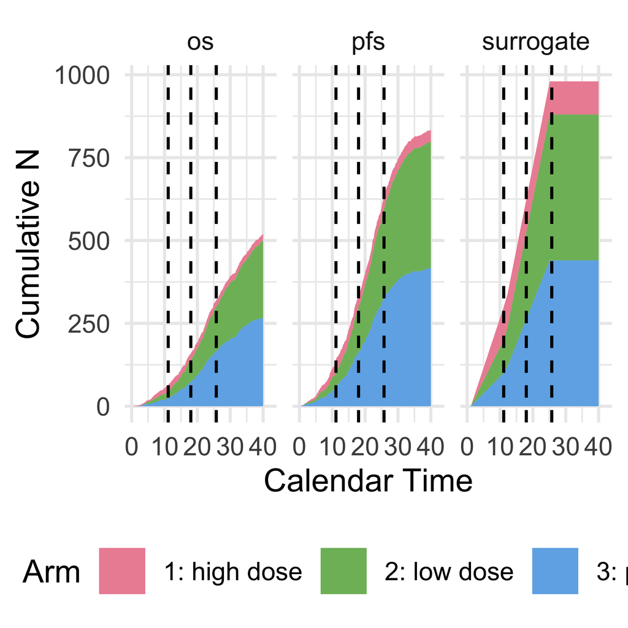

```r
controller <- controller(trial, listener)
controller$run(plot_event = TRUE)
```

In custom action functions, we can use `Trial$save()` to save intermediate results for summary purpose, which can be accessed anytime and anywhere by

```r
controller$get_output() %>%
  kable(escape = FALSE) %>%
  kable_styling(bootstrap_options = "striped",
                full_width = FALSE,
                position = "left") %>%
  scroll_box(width = "100%")
```

| trial | seed | milestone_time_<dose selection> | n_events_<dose selection>_<patient_id> | n_events_<dose selection>_<pfs> | n_events_<dose selection>_<os> | n_events_<dose selection>_<surrogate> | n_events_<dose selection>_<arms> | kept_arm | milestone_time_<interim> | n_events_<interim>_<patient_id> | n_events_<interim>_<pfs> | n_events_<interim>_<os> | n_events_<interim>_<surrogate> | n_events_<interim>_<arms> | futility | milestone_time_<final> | n_events_<final>_<patient_id> | n_events_<final>_<pfs> | n_events_<final>_<os> | n_events_<final>_<surrogate> | n_events_<final>_<arms> | pfs_high_dose_decision | pfs_low_dose_decision | os_high_dose_decision | os_low_dose_decision | error_message |
| --- | --- | --- | --- | --- | --- | --- | --- | --- | --- | --- | --- | --- | --- | --- | --- | --- | --- | --- | --- | --- | --- | --- | --- | --- | --- | --- |
| Trial-3415 | 1727811904 | 11.12051 | 357 | 141 | 65 | 300 | c(119, 4…. | low | 17.99494 | 581 | 300 | 138 | 524 | c(290, 1…. | negative | 25.74756 | 881 | 596 | 300 | 880 | c(441, 2…. | accept | reject | accept | reject |  |

Here we dive into the action function (`action3`) for the final analysis. We can literally execute the function line by line with locked data loaded. Note that the member functions `Trial$dunnettTest` and `Trial$closedTest` can make use of locked data at multiple stages (through the `milestones` argument) automatically, thus, unlike in `action3`, an explicit call of `Trial$get_locked_data('final')` is unnecessary.

```r
## test PFS
dt_pfs <- trial$dunnettTest(Surv(pfs, pfs_event) ~ arm, placebo = 'placebo',
                            treatments = c('high dose', 'low dose'),
                            milestones = c('dose selection', 'interim', 'final'),
                            alternative = 'less',
                            planned_info = 'default')
ct_pfs <- trial$closedTest(dt_pfs, treatments = c('high dose', 'low dose'),
                           milestones = c('interim', 'final'),
                           alpha = .005, alpha_spending = 'asOF')

## test OS
dt_os <- trial$dunnettTest(Surv(os, os_event) ~ arm, placebo = 'placebo',
                           treatments = c('high dose', 'low dose'),
                           milestones = c('dose selection', 'final'),
                           alternative = 'less',
                           planned_info = 'default')
ct_os <- trial$closedTest(dt_pfs, treatments = c('high dose', 'low dose'),
                          milestones = c('final'),
                          alpha = .02, alpha_spending = 'asOF')

print(ct_pfs)
```

```
#>         arm decision milestone_at_reject reject_time
#> 1 high dose   accept                <NA>         Inf
#> 2  low dose   reject               final    25.74756
```

```r
print(ct_os)
```

```
#>         arm decision milestone_at_reject reject_time
#> 1 high dose   accept                <NA>         Inf
#> 2  low dose   reject               final    25.74756
```

The two null hypotheses of `PFS` and `OS` are both accepted for the high dose because it is dropped at dose selection. Thus, `milestone_at_reject` is `NA`, and the `reject_time` is infinite. In contrast, `PFS` and `OS` are significant in low does. Note that even if `PFS` are tested at interim and final, one cannot claim its significance until the final analysis (`milestone_at_reject`). The `reject_time` (25.7475563) can be saved to the output using the member function `Trial$save`.

`TrialSimulator` abstracts the data generation and management to allow user focus on implementing the statistical analysis. It simulates a trial on patient level, and provide flexibility in adaptive design.

## Execute Trial Simulation

We can run a massive number of replicates in simulation to study operating characteristics of a trial design by specifying `n` in `Controller$run()`. We can set `plot_event = FALSE` to turn off plotting to save running time.

```r
## reset a controller if $run has been executed before
controller$reset()
controller$run(n = 1000, plot_event = FALSE, silent = TRUE)
output <- controller$get_output()
```

```r
output %>%
  head(5) %>%
  kable(escape = FALSE) %>%
  kable_styling(bootstrap_options = "striped",
                full_width = FALSE,
                position = "left") %>%
  scroll_box(width = "100%")
```

| trial | seed | milestone_time_<dose selection> | n_events_<dose selection>_<patient_id> | n_events_<dose selection>_<pfs> | n_events_<dose selection>_<os> | n_events_<dose selection>_<surrogate> | n_events_<dose selection>_<arms> | kept_arm | milestone_time_<interim> | n_events_<interim>_<patient_id> | n_events_<interim>_<pfs> | n_events_<interim>_<os> | n_events_<interim>_<surrogate> | n_events_<interim>_<arms> | futility | milestone_time_<final> | n_events_<final>_<patient_id> | n_events_<final>_<pfs> | n_events_<final>_<os> | n_events_<final>_<surrogate> | n_events_<final>_<arms> | pfs_high_dose_decision | pfs_low_dose_decision | os_high_dose_decision | os_low_dose_decision | error_message |
| --- | --- | --- | --- | --- | --- | --- | --- | --- | --- | --- | --- | --- | --- | --- | --- | --- | --- | --- | --- | --- | --- | --- | --- | --- | --- | --- |
| Trial-3415 | 1727811904 | 11.31385 | 366 | 142 | 65 | 300 | c(122, 4…. | low | 19.16584 | 637 | 300 | 146 | 534 | c(319, 1…. | negative | 29.44763 | 878 | 542 | 300 | 744 | c(439, 2…. | accept | reject | accept | reject |  |
| Trial-3415 | 776792356 | 11.33385 | 367 | 139 | 68 | 300 | c(123, 4…. | high | 19.52434 | 654 | 300 | 145 | 544 | c(327, 1…. | negative | 29.56296 | 877 | 520 | 300 | 748 | c(439, 2…. | reject | accept | reject | accept |  |
| Trial-3415 | 1430198130 | 11.41385 | 371 | 138 | 64 | 300 | c(124, 4…. | low | 19.99458 | 677 | 300 | 158 | 554 | c(339, 1…. | negative | 30.26166 | 877 | 546 | 300 | 740 | c(439, 2…. | accept | reject | accept | reject |  |
| Trial-3415 | 1400866922 | 11.29385 | 365 | 154 | 65 | 300 | c(122, 4…. | high | 19.48899 | 653 | 300 | 140 | 547 | c(326, 1…. | negative | 28.74682 | 878 | 541 | 300 | 755 | c(439, 2…. | reject | accept | reject | accept |  |
| Trial-3415 | 1898009641 | 11.19385 | 360 | 131 | 60 | 300 | c(120, 4…. | low | 19.73958 | 667 | 300 | 151 | 550 | c(334, 1…. | negative | 28.64718 | 880 | 534 | 300 | 743 | c(440, 2…. | accept | reject | accept | reject |  |

```r
output %>%
  summarise(
    time_dose_selection = mean(`milestone_time_<dose selection>`),
    time_interim = mean(`milestone_time_<interim>`),
    time_final = mean(`milestone_time_<final>`),
    n_dose_selection = mean(`n_events_<dose selection>_<patient_id>`),
    n_interim = mean(`n_events_<interim>_<patient_id>`),
    n_final = mean(`n_events_<final>_<patient_id>`),
    low = mean(kept_arm == 'low') * 100,
    high = mean(kept_arm == 'high') * 100,
    both = mean(kept_arm == 'both') * 100
  ) %>%
  kable(col.names = NULL, digits = 1, align = 'r',
        caption = 'Number of Randomized Patients at Stages') %>%
  add_header_above(c(rep(c('Dose Selection', 'Interim', 'Final'), 2),
                     'Low Dose', 'High Dose', 'Both'), align = 'r') %>%
  add_header_above(c('Time' = 3, 'Number of Patients' = 3, 'Selected Dose (%)' = 3)) %>%
  kable_styling(full_width = TRUE)
```

Number of Randomized Patients at Stages

| Time Dose Selection | Time Interim | Time Final | Number of Patients Dose Selection | Number of Patients Interim | Number of Patients Final | Selected Dose (%) Low Dose | Selected Dose (%) High Dose | Selected Dose (%) Both |
| --- | --- | --- | --- | --- | --- | --- | --- | --- |
| 11.3 | 19.1 | 28 | 365 | 647.6 | 893.2 | 70.5 | 17.3 | 12.2 |

```r
output %>%
  summarise(
    n_pfs_dose_selection = mean(`n_events_<dose selection>_<pfs>`),
    n_pfs_interim = mean(`n_events_<interim>_<pfs>`),
    n_pfs_final = mean(`n_events_<final>_<pfs>`),
    n_os_dose_selection = mean(`n_events_<dose selection>_<os>`),
    n_os_interim = mean(`n_events_<interim>_<os>`),
    n_os_final = mean(`n_events_<final>_<os>`)
  ) %>%
  kable(col.names = NULL, digits = 1, align = 'r',
        caption = 'Number of Events of PFS and OS at Stages') %>%
  add_header_above(rep(c('Dose Selection', 'Interim', 'Final'), 2), align = 'r') %>%
  add_header_above(c('PFS' = 3, 'OS' = 3)) %>%
  kable_styling(full_width = TRUE)
```

Number of Events of PFS and OS at Stages

| PFS Dose Selection | PFS Interim | PFS Final | OS Dose Selection | OS Interim | OS Final |
| --- | --- | --- | --- | --- | --- |
| 144.4 | 300 | 532.8 | 67.9 | 152.2 | 301.9 |

```r
output %>%
  summarise(
    power_pfs_low = mean(pfs_low_dose_decision == 'reject') * 100,
    power_pfs_high = mean(pfs_high_dose_decision == 'reject') * 100,
    power_pfs_or = mean(pfs_low_dose_decision == 'reject' | pfs_high_dose_decision == 'reject') * 100,
    power_pfs_and = mean(pfs_low_dose_decision == 'reject' & pfs_high_dose_decision == 'reject') * 100,
    power_os_low = mean(os_low_dose_decision == 'reject') * 100,
    power_os_high = mean(os_high_dose_decision == 'reject') * 100,
    power_os_or = mean(os_low_dose_decision == 'reject' | os_high_dose_decision == 'reject') * 100,
    power_os_and = mean(os_low_dose_decision == 'reject' & os_high_dose_decision == 'reject') * 100
  ) %>%
  kable(col.names = NULL, digits = 1, align = 'r',
        caption = 'Power of Testing PFS and OS') %>%
  add_header_above(rep(c('Low Dose', 'High Dose', 'Low or High', 'Low and High'), 2), align = 'r') %>%
  add_header_above(c('PFS (%)' = 4, 'OS (%)' = 4)) %>%
  kable_styling(full_width = TRUE)
```

Power of Testing PFS and OS

| PFS (%) Low Dose | PFS (%) High Dose | PFS (%) Low or High | PFS (%) Low and High | OS (%) Low Dose | OS (%) High Dose | OS (%) Low or High | OS (%) Low and High |
| --- | --- | --- | --- | --- | --- | --- | --- |
| 57.6 | 24.6 | 75.4 | 6.8 | 72.1 | 27.4 | 90.6 | 8.9 |

```r
output %>%
  summarise(
    power_pfs_not_os = mean((pfs_low_dose_decision == 'reject' | pfs_high_dose_decision == 'reject') &
                              os_low_dose_decision == 'accept' & os_high_dose_decision == 'accept') * 100,
    power_os_not_pfs = mean((os_low_dose_decision == 'reject' | os_high_dose_decision == 'reject') &
                              pfs_low_dose_decision == 'accept' & pfs_high_dose_decision == 'accept') * 100,
    power_pfs_and_os = mean((pfs_low_dose_decision == 'reject' | pfs_high_dose_decision == 'reject') &
                              (os_low_dose_decision == 'reject' | os_high_dose_decision == 'reject')) * 100,
    power_pfs_or_os = mean((pfs_low_dose_decision == 'reject' | pfs_high_dose_decision == 'reject') |
                              (os_low_dose_decision == 'reject' | os_high_dose_decision == 'reject')) * 100
  ) %>%
  kable(col.names = NULL, digits = 1, align = 'r',
        caption = 'Power of Testing PFS and OS (Cont.)') %>%
  add_header_above(c('Reject PFS and Accept OS', 'Accept PFS and Reject OS',
                     'Reject PFS and OS', 'Reject PFS or OS'), align = 'r') %>%
  kable_styling(full_width = TRUE)
```

Power of Testing PFS and OS (Cont.)

| Reject PFS and Accept OS | Accept PFS and Reject OS | Reject PFS and OS | Reject PFS or OS |
| --- | --- | --- | --- |
| 0 | 15.2 | 75.4 | 90.6 |